# Project in Supervised Learning

```python
import pandas as pd
import numpy as np
import seaborn as sns
import matplotlib.pyplot as plt
import scipy.stats as stats
from sklearn import metrics
from sklearn.model_selection import train_test_split
from sklearn.neighbors import KNeighborsClassifier
from sklearn.metrics import accuracy_score
from sklearn.linear_model import LogisticRegression
from sklearn.metrics import accuracy_score
from sklearn.metrics import precision_score
from sklearn.metrics import recall_score
from sklearn.metrics import f1_score
from sklearn.metrics import classification_report
```

# PART - A

### Data Understanding

##### A: Read the CSV content into Python Dataframe

```python
# We are given with three CSV files. They are Part1_Normal.csv, Part1_Type_H, Part1_Type_S

normal_data = pd.read_csv('Part1_Normal.csv');
type_hdata = pd.read_csv('Part1_Type_H.csv');
type_sdata = pd.read_csv('Part1_Type_S.csv');
```

##### B.1: Print the shape of all three data frame

```python
print(f"Shape of Normale Data is {normal_data.shape}", f"Shape of H Data is {type_hdata.shape}",
      f"Shape of S Data is {type_sdata.shape}", sep='\n')
```

```
Shape of Normale Data is (100, 7)
Shape of H Data is (60, 7)
Shape of S Data is (150, 7)
```

##### B.2: Print all the columns of all three data frame

```python
print(f"Column of Normale Data is {normal_data.columns}", f"Column of H Data is {type_hdata.columns}",
      f"Column of S Data is {type_sdata.columns}", sep='\n')
```

```
Column of Normale Data is Index(['P_incidence', 'P_tilt', 'L_angle', 'S_slope', 'P_radius', 'S_Degree',
       'Class'],
      dtype='object')
Column of H Data is Index(['P_incidence', 'P_tilt', 'L_angle', 'S_slope', 'P_radius', 'S_Degree',
       'Class'],
      dtype='object')
Column of S Data is Index(['P_incidence', 'P_tilt', 'L_angle', 'S_slope', 'P_radius', 'S_Degree',
       'Class'],
      dtype='object')
```

##### C: Compare Column names of all the 3 DataFrames and clearly write observations

##### Observations are

###### All the three dataframe has excactly same set of column

###### The Dataframe can be merged to single dataframe which will form three different class for Target

##### D: Print DataTypes of all the 3 DataFrames

```python
print(normal_data.head(2))
normal_data.dtypes
```

```
   P_incidence     P_tilt    L_angle    S_slope    P_radius  S_Degree   Class
0    38.505273  16.964297  35.112814  21.540976  127.632875  7.986683  Normal
1    54.920858  18.968430  51.601455  35.952428  125.846646  2.001642  Normal
```

```
P_incidence    float64
P_tilt         float64
L_angle        float64
S_slope        float64
P_radius       float64
S_Degree       float64
Class           object
dtype: object
```

```python
print(type_hdata.head(2))
type_hdata.dtypes
#type_hdata.index.duplicated()
```

```
   P_incidence     P_tilt    L_angle    S_slope    P_radius  S_Degree   Class
0    63.027817  22.552586  39.609117  40.475232   98.672917 -0.254400  Type_H
1    39.056951  10.060991  25.015378  28.995960  114.405425  4.564259  Type_H
```

```
P_incidence    float64
P_tilt         float64
L_angle        float64
S_slope        float64
P_radius       float64
S_Degree       float64
Class           object
dtype: object
```

```python
print(type_sdata.head(2))
type_sdata.dtypes
```

```
   P_incidence     P_tilt    L_angle    S_slope    P_radius   S_Degree   Class
0    74.377678  32.053104  78.772013  42.324573  143.560690  56.125906  Type_S
1    89.680567  32.704435  83.130732  56.976132  129.955476  92.027277  Type_S
```

```
P_incidence    float64
P_tilt         float64
L_angle        float64
S_slope        float64
P_radius       float64
S_Degree       float64
Class           object
dtype: object
```

###### The dataframe has same feature with same data type. There are 7 column with Float and Object data type.

##### E: Observe and share variation in ‘Class’ feature of all the 3 DaraFrames

```python
print(normal_data.groupby(['Class'])['Class'].count())
print(type_hdata.groupby(['Class'])['Class'].count())
print(type_sdata.groupby(['Class'])['Class'].count())
```

```
Class
Normal    73
Nrmal     27
Name: Class, dtype: int64
Class
Type_H    37
type_h    23
Name: Class, dtype: int64
Class
Type_S    133
tp_s       17
Name: Class, dtype: int64
```

###### The Class 'Nrmal', 'type_h', 'tp_s' should be imputed (replaced with proper class name) because it should mostly be a typo error

### Data Preparation and Exploration

##### A: Unify all the variations in ‘Class’ feature for all the 3 DataFrames

###### Nrmal - To be changed as Normal

###### type_h - To be changed as Type_H

###### tp_s - To be changed as Type_S

###### We can change the Class as 'Category' Type

```python
normal_data['Class'].replace('Nrmal','Normal',inplace=True)
type_hdata['Class'].replace('type_h','Type_H',inplace=True)
type_sdata['Class'].replace('tp_s','Type_S',inplace=True)
```

##### B: Combine all the 3 DataFrames to form a single DataFrame

```python
medical_data = pd.concat([normal_data,type_hdata,type_sdata],join='inner',axis=0)
medical_data.shape
```

```
(310, 7)
```

##### C: Print 5 random samples of this DataFrame

```python
medical_data.sample(n=5)
```

|  | P_incidence | P_tilt | L_angle | S_slope | P_radius | S_Degree | Class |
| --- | --- | --- | --- | --- | --- | --- | --- |
| 12 | 84.974132 | 33.021175 | 60.859873 | 51.952957 | 125.659534 | 74.333409 | Type_S |
| 1 | 89.680567 | 32.704435 | 83.130732 | 56.976132 | 129.955476 | 92.027277 | Type_S |
| 39 | 50.753290 | 20.235060 | 37.000000 | 30.518231 | 122.343516 | 2.288488 | Normal |
| 41 | 79.938570 | 18.774071 | 63.311835 | 61.164499 | 114.787107 | 38.538741 | Type_S |
| 89 | 82.905351 | 29.894119 | 58.250542 | 53.011232 | 110.708958 | 6.079338 | Normal |

##### D: Print Feature-wise percentage of Null values

```python
medical_data.info()
medical_data.isnull().sum() * 100 / len(medical_data)
```

```
<class 'pandas.core.frame.DataFrame'>
Int64Index: 310 entries, 0 to 149
Data columns (total 7 columns):
 #   Column       Non-Null Count  Dtype
---  ------       --------------  -----
 0   P_incidence  310 non-null    float64
 1   P_tilt       310 non-null    float64
 2   L_angle      310 non-null    float64
 3   S_slope      310 non-null    float64
 4   P_radius     310 non-null    float64
 5   S_Degree     310 non-null    float64
 6   Class        310 non-null    object
dtypes: float64(6), object(1)
memory usage: 19.4+ KB
```

```
P_incidence    0.0
P_tilt         0.0
L_angle        0.0
S_slope        0.0
P_radius       0.0
S_Degree       0.0
Class          0.0
dtype: float64
```

###### We can confirm that there is no NULL in the dataset

##### Convert the Class as Category column and verify

```python
medical_data['Class']=medical_data['Class'].astype('category')
medical_data.info()
```

```
<class 'pandas.core.frame.DataFrame'>
Int64Index: 310 entries, 0 to 149
Data columns (total 7 columns):
 #   Column       Non-Null Count  Dtype
---  ------       --------------  -----
 0   P_incidence  310 non-null    float64
 1   P_tilt       310 non-null    float64
 2   L_angle      310 non-null    float64
 3   S_slope      310 non-null    float64
 4   P_radius     310 non-null    float64
 5   S_Degree     310 non-null    float64
 6   Class        310 non-null    category
dtypes: category(1), float64(6)
memory usage: 17.4 KB
```

##### E: Check 5-point summary of the new DataFrame

```python
medical_data.describe(include='all')
```

|  | P_incidence | P_tilt | L_angle | S_slope | P_radius | S_Degree | Class |
| --- | --- | --- | --- | --- | --- | --- | --- |
| count | 310.000000 | 310.000000 | 310.000000 | 310.000000 | 310.000000 | 310.000000 | 310 |
| unique | NaN | NaN | NaN | NaN | NaN | NaN | 3 |
| top | NaN | NaN | NaN | NaN | NaN | NaN | Type_S |
| freq | NaN | NaN | NaN | NaN | NaN | NaN | 150 |
| mean | 60.496653 | 17.542822 | 51.930930 | 42.953831 | 117.920655 | 26.296694 | NaN |
| std | 17.236520 | 10.008330 | 18.554064 | 13.423102 | 13.317377 | 37.559027 | NaN |
| min | 26.147921 | -6.554948 | 14.000000 | 13.366931 | 70.082575 | -11.058179 | NaN |
| 25% | 46.430294 | 10.667069 | 37.000000 | 33.347122 | 110.709196 | 1.603727 | NaN |
| 50% | 58.691038 | 16.357689 | 49.562398 | 42.404912 | 118.268178 | 11.767934 | NaN |
| 75% | 72.877696 | 22.120395 | 63.000000 | 52.695888 | 125.467674 | 41.287352 | NaN |
| max | 129.834041 | 49.431864 | 125.742385 | 121.429566 | 163.071041 | 418.543082 | NaN |

###### The feature P_incidence, S_slope, L_angle, S_slope mean and median are very close.

###### The P_incidence, S_slope, L_angle seem to be normal with small right skeweness

###### The P_tilt seem to be normal with negative value

###### The P_radius looks like normal

###### The S_Degree might have some outliers

###### We have three class of target

### Data Analysis

##### A: Visualize a heatmap to understand correlation between all features

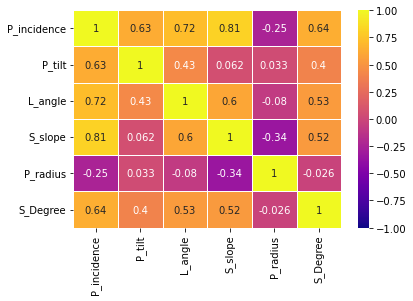

```python
sns.heatmap(medical_data.corr(), cmap="plasma", vmin=-1, vmax=1, annot=True, linewidth=1)
```

##### B: Share insights on correlation

##### P_incidence and S_slope has good positive correlation.

##### P_incidence and L_angle is also have good correlation

##### S_Degree & P_radius, L_angle & P_radius, S_slope and P_tilt are all having close to zero correlation - Indepedent ?

###### B.1: Features having stronger correlation with correlation value.

```python
#### Helper function to return correlated feature with in the min and max
#### threashold. This should take care of removing diagnoal data, etc.
#### The returned corr_set will have feature in the correlated context and its
#### correlation value
def getCorrWithFeatureByMinAndMax(corr_mat, min_threashold, max_threashold):
    data = corr_mat.unstack().sort_values()
    #print(data)
    corr_set=set()
    for items in data.iteritems():
        if (np.abs(items[1]) > min_threashold and np.abs(items[1]) <= max_threashold):
            if (items[0][0] != items[0][1]):   # Ignore same feature will show always = 1
                not_unique = int(0)
                if (len(corr_set) == 0):
                    corr_set.add(items)
                for item in corr_set:
                    if (item[1] == items[1]):
                        elements = set(item[0]) & set(items[0])
                        if (len(elements) == 2):
                            not_unique = 1;
                if (not_unique == 0):
                    corr_set.add(items)
    return corr_set
```

```python
corr_mat = medical_data.corr()
print("Strong correlated feature is following ")
getCorrWithFeatureByMinAndMax(corr_mat, 0.7, 1.0)
```

```
Strong correlated feature is following
```

```
{(('L_angle', 'P_incidence'), 0.717282364274049),
 (('P_incidence', 'S_slope'), 0.8149599891850364)}
```

###### B.2: Features having weaker correlation with correlation value.

```python
print("Weak correlated feature is following ")
getCorrWithFeatureByMinAndMax(corr_mat, 0.25, 0.5)
```

```
Weak correlated feature is following
```

```
{(('L_angle', 'P_tilt'), 0.43276386444815157),
 (('P_radius', 'S_slope'), -0.34212834910432577),
 (('P_tilt', 'S_Degree'), 0.3978622794847845)}
```

##### C: Visualize a pairplot with 3 classes distinguished by colors and share insights

```python
##### Below SNS pairplot calls results in "ValueError: cannot reindex from a duplicate axis"

# sns.pairplot(medical_data,diag_kind='kde')
```

```python
medical_data.index.duplicated()
```

[output not shown]

###### All true means the index is duplicate of one already exists. We need to remove the duplicate index

###### To remove duplicate index we have following code

```python
#duplicates = medical_data[medical_data.index.duplicated()]
duplicates = medical_data[medical_data.index.duplicated(keep=False)]
#print(duplicates)
#print(duplicates.to_string())
#medical_data.groupby(level=0).filter(lambda x: len(x) > 1)
df = medical_data.reset_index(drop=True)
print(df.to_string())
df.shape
```

[output not shown]

[output cut: 296 more lines]

```
(310, 7)
```

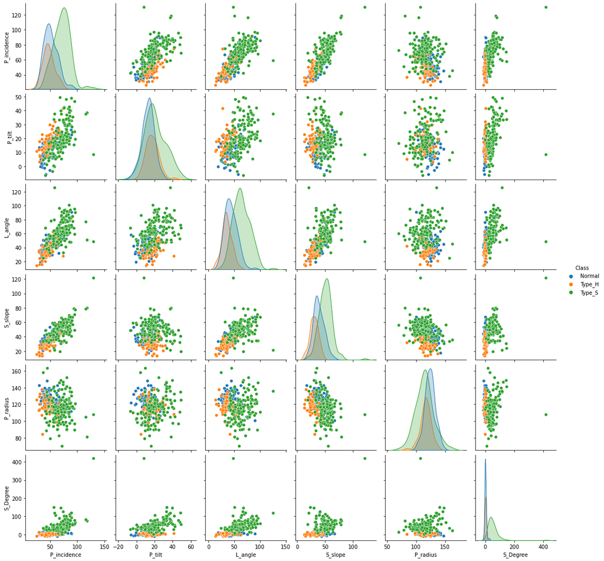

```python
sns.pairplot(df,hue='Class',diag_kind='kde')
```

###### We have many distribution with Class Type_S

###### We have less number of distibution with class Type_H

##### D: Visualize a jointplot for ‘P_incidence’ and ‘S_slope’ and share insights

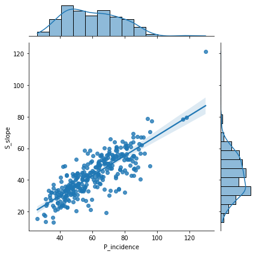

```python
sns.jointplot(x='P_incidence',y='S_slope',data=df, kind='reg')
```

##### E: Visualize a boxplot to check distribution of the features and share insights

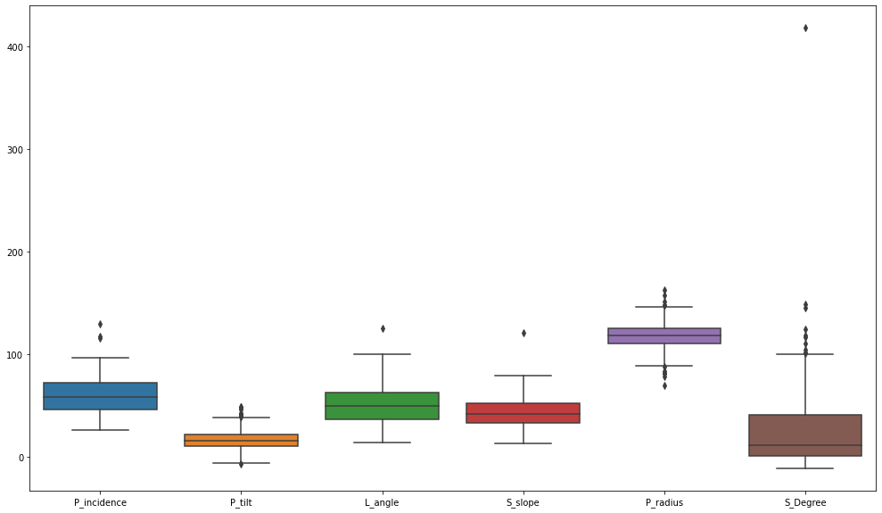

```python
plt.figure(figsize=(17,10))
sns.boxplot(data=df)
```

###### S_Degree is having lot of outlier and has large value. The data is right skewed.

###### Except S_Degree - features are showing normal spread of data with outliers.

###### P_radius is having equal number of outlier in both upper and lower Quartile range

###### L_angle, S_Slope and P_incidence shows lesser outlier

###### P_tilt shows outlier close to the range.

### Model Building

##### A: Split data into X and Y.

```python
X = df.drop('Class',axis=1)
Y = df['Class']

print(X.sample(2))
print(Y.sample(3))
```

```
     P_incidence     P_tilt    L_angle    S_slope    P_radius   S_Degree
274    61.411737  25.384364  39.096869  36.027373  103.404597  21.843407
192    85.352315  15.844910  71.668660  69.507405  124.419787  76.020603
108    Type_H
58     Normal
197    Type_S
Name: Class, dtype: category
Categories (3, object): ['Normal', 'Type_H', 'Type_S']
```

##### B: Split data into train and test with 80:20 proportion

```python
X_train, X_test, y_train, y_test = train_test_split(X, Y, test_size=0.2, random_state=1)
# 1 is just any random seed number

print(f"{X_train.shape} is X_train shape, {X_test.shape} X_test shape, {y_train.shape} is y_train shape, {y_test.shape} y_test shape")
X_train.head()
```

```
(248, 6) is X_train shape, (62, 6) X_test shape, (248,) is y_train shape, (62,) y_test shape
```

|  | P_incidence | P_tilt | L_angle | S_slope | P_radius | S_Degree |
| --- | --- | --- | --- | --- | --- | --- |
| 307 | 74.094731 | 18.823727 | 76.032156 | 55.271004 | 128.405731 | 73.388216 |
| 0 | 38.505273 | 16.964297 | 35.112814 | 21.540976 | 127.632875 | 7.986683 |
| 132 | 44.936675 | 17.443838 | 27.780576 | 27.492837 | 117.980324 | 5.569620 |
| 208 | 63.172987 | 6.330911 | 63.000000 | 56.842076 | 110.644021 | 42.608076 |
| 62 | 39.358705 | 7.011262 | 37.000000 | 32.347443 | 117.818760 | 1.904048 |

##### C: Train a Supervised Learning Classification base model using KNN classifier

```python
NNH = KNeighborsClassifier(n_neighbors=5, weights = 'distance' )
NNH.fit(X_train, y_train)
```

```
KNeighborsClassifier(weights='distance')
```

##### D: Print all the possible performance metrics for both train and test data

```python
predicted_labels = NNH.predict(X_test)
#print(predicted_labels)
print(NNH.score(X_test, y_test))
#print(NNH.score(X_train, y_train))
```

```
0.8548387096774194
```

```
Type_S    33
Normal    18
Type_H    11
Name: Class, dtype: int64
[[16  1  1]
 [ 4  7  0]
 [ 2  1 30]]
```

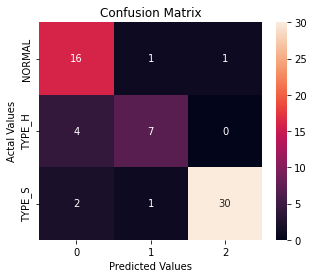

```python
cm = metrics.confusion_matrix(y_test, predicted_labels)
print(y_test.value_counts())
print(cm)
cm_df = pd.DataFrame(cm,
                     index = ['NORMAL','TYPE_H','TYPE_S'])
plt.figure(figsize=(5,4))
sns.heatmap(cm_df, annot=True)
plt.title('Confusion Matrix')
plt.ylabel('Actal Values')
plt.xlabel('Predicted Values')
plt.show()
### https://www.analyticsvidhya.com/blog/2021/06/confusion-matrix-for-multi-class-classification/
```

```python
print(f"accuracy = {accuracy_score(y_test, predicted_labels)} precision = "
      f"{precision_score(y_test, predicted_labels,average='weighted')}, recall = "
      f"{recall_score(y_test, predicted_labels,average='weighted')}, f1 = "
      f"{f1_score(y_test, predicted_labels,average='weighted')}")
```

```
accuracy = 0.8548387096774194 precision = 0.8642249760876193, recall = 0.8548387096774194, f1 = 0.8554435483870967
```

### Performance Improvement

##### A: Experiment with various parameters to improve performance of the base model

##### KNeighborsClassifier has following parameters

##### K/n_neighbor - Choose right K value

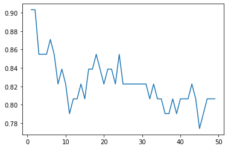

```python
scores =[]
for k in range(1,50):
    NNH = KNeighborsClassifier(n_neighbors = k, weights = 'distance' )
    NNH.fit(X_train, y_train)
    scores.append(NNH.score(X_test, y_test))
plt.plot(range(1,50),scores)
```

```python
NNH = KNeighborsClassifier(n_neighbors=5, weights = 'distance')
NNH.fit(X_train, y_train)
predicted_labels = NNH.predict(X_test)
NNH.score(X_test, y_test)
print(f"accuracy = {accuracy_score(y_test, predicted_labels)} precision = "
      f"{precision_score(y_test, predicted_labels,average='weighted')}, recall = "
      f"{recall_score(y_test, predicted_labels,average='weighted')}, f1 = "
      f"{f1_score(y_test, predicted_labels,average='weighted')}")
print("classification  Matrix:\n",classification_report(y_test,predicted_labels))
```

```
accuracy = 0.8548387096774194 precision = 0.8642249760876193, recall = 0.8548387096774194, f1 = 0.8554435483870967
classification  Matrix:
               precision    recall  f1-score   support

      Normal       0.73      0.89      0.80        18
      Type_H       0.78      0.64      0.70        11
      Type_S       0.97      0.91      0.94        33

    accuracy                           0.85        62
   macro avg       0.82      0.81      0.81        62
weighted avg       0.86      0.85      0.86        62
```

```python
NNH = KNeighborsClassifier(n_neighbors=3, weights = 'distance')
NNH.fit(X_train, y_train)
predicted_labels = NNH.predict(X_test)
NNH.score(X_test, y_test)
print(f"accuracy = {accuracy_score(y_test, predicted_labels)} precision = "
      f"{precision_score(y_test, predicted_labels,average='weighted')}, recall = "
      f"{recall_score(y_test, predicted_labels,average='weighted')}, f1 = "
      f"{f1_score(y_test, predicted_labels,average='weighted')}")
print("classification  Matrix:\n",classification_report(y_test,predicted_labels))
```

```
accuracy = 0.8548387096774194 precision = 0.8642249760876193, recall = 0.8548387096774194, f1 = 0.8554435483870967
classification  Matrix:
               precision    recall  f1-score   support

      Normal       0.73      0.89      0.80        18
      Type_H       0.78      0.64      0.70        11
      Type_S       0.97      0.91      0.94        33

    accuracy                           0.85        62
   macro avg       0.82      0.81      0.81        62
weighted avg       0.86      0.85      0.86        62
```

```python
NNH = KNeighborsClassifier(n_neighbors=7, p=1, n_jobs=3, weights = 'distance')
NNH.fit(X_train, y_train)
predicted_labels = NNH.predict(X_test)
NNH.score(X_test, y_test)
print(f"accuracy = {accuracy_score(y_test, predicted_labels)} precision = "
      f"{precision_score(y_test, predicted_labels,average='weighted')}, recall = "
      f"{recall_score(y_test, predicted_labels,average='weighted')}, f1 = "
      f"{f1_score(y_test, predicted_labels,average='weighted')}")
print("classification  Matrix:\n",classification_report(y_test,predicted_labels))
```

```
accuracy = 0.8548387096774194 precision = 0.8649695257915861, recall = 0.8548387096774194, f1 = 0.8577576657213754
classification  Matrix:
               precision    recall  f1-score   support

      Normal       0.71      0.83      0.77        18
      Type_H       0.90      0.82      0.86        11
      Type_S       0.94      0.88      0.91        33

    accuracy                           0.85        62
   macro avg       0.85      0.84      0.84        62
weighted avg       0.86      0.85      0.86        62
```

```python
NNH = KNeighborsClassifier(n_neighbors=9, p=2, weights = 'distance')
NNH.fit(X_train, y_train)
predicted_labels = NNH.predict(X_test)
NNH.score(X_test, y_test)
print(f"accuracy = {accuracy_score(y_test, predicted_labels)} precision = "
      f"{precision_score(y_test, predicted_labels,average='weighted')}, recall = "
      f"{recall_score(y_test, predicted_labels,average='weighted')}, f1 = "
      f"{f1_score(y_test, predicted_labels,average='weighted')}")
print("classification  Matrix:\n",classification_report(y_test,predicted_labels))
```

```
accuracy = 0.8387096774193549 precision = 0.8438321048022186, recall = 0.8387096774193549, f1 = 0.840047855370436
classification  Matrix:
               precision    recall  f1-score   support

      Normal       0.76      0.72      0.74        18
      Type_H       0.69      0.82      0.75        11
      Type_S       0.94      0.91      0.92        33

    accuracy                           0.84        62
   macro avg       0.80      0.82      0.81        62
weighted avg       0.84      0.84      0.84        62
```

##### B: Clearly showcase improvement in performance achieved

###### With K = 9 The performance is dropping again.

##### C: Clearly state which parameters contributed most to improve model performance

```python
NNH = KNeighborsClassifier(n_neighbors=7, p=1, n_jobs=3, weights = 'distance')
NNH.fit(X_train, y_train)
predicted_labels = NNH.predict(X_test)
NNH.score(X_test, y_test)
print(f"accuracy = {accuracy_score(y_test, predicted_labels)} precision = "
      f"{precision_score(y_test, predicted_labels,average='weighted')}, recall = "
      f"{recall_score(y_test, predicted_labels,average='weighted')}, f1 = "
      f"{f1_score(y_test, predicted_labels,average='weighted')}")
print("classification  Matrix:\n",classification_report(y_test,predicted_labels))
```

```
accuracy = 0.8548387096774194 precision = 0.8649695257915861, recall = 0.8548387096774194, f1 = 0.8577576657213754
classification  Matrix:
               precision    recall  f1-score   support

      Normal       0.71      0.83      0.77        18
      Type_H       0.90      0.82      0.86        11
      Type_S       0.94      0.88      0.91        33

    accuracy                           0.85        62
   macro avg       0.85      0.84      0.84        62
weighted avg       0.86      0.85      0.86        62
```

```python
NNH = KNeighborsClassifier(n_neighbors=7, p=1, weights = 'distance')
NNH.fit(X_train, y_train)
predicted_labels = NNH.predict(X_test)
NNH.score(X_test, y_test)
print(f"accuracy = {accuracy_score(y_test, predicted_labels)} precision = "
      f"{precision_score(y_test, predicted_labels,average='weighted')}, recall = "
      f"{recall_score(y_test, predicted_labels,average='weighted')}, f1 = "
      f"{f1_score(y_test, predicted_labels,average='weighted')}")
print("classification  Matrix:\n",classification_report(y_test,predicted_labels))
```

```
accuracy = 0.8548387096774194 precision = 0.8649695257915861, recall = 0.8548387096774194, f1 = 0.8577576657213754
classification  Matrix:
               precision    recall  f1-score   support

      Normal       0.71      0.83      0.77        18
      Type_H       0.90      0.82      0.86        11
      Type_S       0.94      0.88      0.91        33

    accuracy                           0.85        62
   macro avg       0.85      0.84      0.84        62
weighted avg       0.86      0.85      0.86        62
```

# PART - B

### Data Understanding and Preparation

##### A. Read both the Datasets ‘Data1’ and ‘Data 2’ as DataFrame and store them into two separate variables.

```python
data1 = pd.read_csv('Part2_Data1.csv')
data2 = pd.read_csv('Part2_Data2.csv')
```

##### B. Print shape and Column Names and DataTypes of both the Dataframes

```python
print(f"Shape of data1 is {data1.shape} and shape of data2 is {data2.shape}")
print(end='\n')
print(f"Columsn List of data1 is {data1.columns}")
print(f"Column List of data2 is {data2.columns}",end='\n')
print(end='\n')
print(data1.info())
print(end='\n')
print(data2.info())
```

```
Shape of data1 is (5000, 8) and shape of data2 is (5000, 7)

Columsn List of data1 is Index(['ID', 'Age', 'CustomerSince', 'HighestSpend', 'ZipCode', 'HiddenScore',
       'MonthlyAverageSpend', 'Level'],
      dtype='object')
Column List of data2 is Index(['ID', 'Mortgage', 'Security', 'FixedDepositAccount', 'InternetBanking',
       'CreditCard', 'LoanOnCard'],
      dtype='object')

<class 'pandas.core.frame.DataFrame'>
RangeIndex: 5000 entries, 0 to 4999
Data columns (total 8 columns):
 #   Column               Non-Null Count  Dtype
---  ------               --------------  -----
 0   ID                   5000 non-null   int64
 1   Age                  5000 non-null   int64
 2   CustomerSince        5000 non-null   int64
 3   HighestSpend         5000 non-null   int64
 4   ZipCode              5000 non-null   int64
 5   HiddenScore          5000 non-null   int64
 6   MonthlyAverageSpend  5000 non-null   float64
 7   Level                5000 non-null   int64
dtypes: float64(1), int64(7)
memory usage: 312.6 KB
None

<class 'pandas.core.frame.DataFrame'>
RangeIndex: 5000 entries, 0 to 4999
Data columns (total 7 columns):
 #   Column               Non-Null Count  Dtype
---  ------               --------------  -----
 0   ID                   5000 non-null   int64
 1   Mortgage             5000 non-null   int64
 2   Security             5000 non-null   int64
 3   FixedDepositAccount  5000 non-null   int64
 4   InternetBanking      5000 non-null   int64
 5   CreditCard           5000 non-null   int64
 6   LoanOnCard           4980 non-null   float64
dtypes: float64(1), int64(6)
memory usage: 273.6 KB
None
```

##### C. Merge both the Dataframes on ‘ID’ feature to form a single DataFrame

```python
df2 = data1.merge(data2, on='ID')
df2.sample(n=10)
```

|  | ID | Age | CustomerSince | HighestSpend | ZipCode | HiddenScore | MonthlyAverageSpend | Level | Mortgage | Security | FixedDepositAccount | InternetBanking | CreditCard | LoanOnCard |
| --- | --- | --- | --- | --- | --- | --- | --- | --- | --- | --- | --- | --- | --- | --- |
| 3323 | 3324 | 60 | 35 | 20 | 92110 | 1 | 1.3 | 1 | 0 | 0 | 0 | 1 | 0 | 0.0 |
| 4922 | 4923 | 31 | 5 | 28 | 90717 | 1 | 0.3 | 1 | 0 | 0 | 0 | 1 | 1 | 0.0 |
| 158 | 159 | 32 | 6 | 79 | 94720 | 2 | 1.5 | 3 | 0 | 0 | 0 | 1 | 1 | 0.0 |
| 1351 | 1352 | 59 | 35 | 84 | 94588 | 1 | 1.8 | 3 | 0 | 0 | 0 | 1 | 1 | 0.0 |
| 3291 | 3292 | 53 | 28 | 38 | 94998 | 1 | 1.3 | 2 | 0 | 0 | 0 | 1 | 0 | 0.0 |
| 3537 | 3538 | 60 | 34 | 19 | 92093 | 3 | 0.3 | 3 | 0 | 0 | 0 | 1 | 0 | 0.0 |
| 688 | 689 | 44 | 20 | 71 | 94304 | 4 | 1.9 | 1 | 207 | 0 | 0 | 1 | 0 | 0.0 |
| 695 | 696 | 29 | 4 | 115 | 92717 | 1 | 1.9 | 1 | 0 | 0 | 0 | 0 | 0 | 0.0 |
| 774 | 775 | 55 | 29 | 39 | 92154 | 1 | 0.2 | 1 | 0 | 0 | 0 | 0 | 1 | 0.0 |
| 673 | 674 | 34 | 10 | 22 | 95670 | 1 | 0.5 | 3 | 85 | 0 | 0 | 0 | 0 | 0.0 |

###### The feature like CustomerSince, HighestSpend and Mortgage might need scaling

##### D. Change Datatype of below features to ‘Object’ (ie) ‘CreditCard’, ‘InternetBanking’, ‘FixedDepositAccount’, ‘Security’, ‘Level’, ‘HiddenScore'

```python
for column in ['CreditCard','InternetBanking','FixedDepositAccount','Security','Level','HiddenScore']:
        df2[column] = df2[column].astype('category')
df2.info()
```

```
<class 'pandas.core.frame.DataFrame'>
Int64Index: 5000 entries, 0 to 4999
Data columns (total 14 columns):
 #   Column               Non-Null Count  Dtype
---  ------               --------------  -----
 0   ID                   5000 non-null   int64
 1   Age                  5000 non-null   int64
 2   CustomerSince        5000 non-null   int64
 3   HighestSpend         5000 non-null   int64
 4   ZipCode              5000 non-null   int64
 5   HiddenScore          5000 non-null   category
 6   MonthlyAverageSpend  5000 non-null   float64
 7   Level                5000 non-null   category
 8   Mortgage             5000 non-null   int64
 9   Security             5000 non-null   category
 10  FixedDepositAccount  5000 non-null   category
 11  InternetBanking      5000 non-null   category
 12  CreditCard           5000 non-null   category
 13  LoanOnCard           4980 non-null   float64
dtypes: category(6), float64(2), int64(6)
memory usage: 381.7 KB
```

### Data Exploration and Analysis

```python
df2.describe(include='all').T
```

|  | count | unique | top | freq | mean | std | min | 25% | 50% | 75% | max |
| --- | --- | --- | --- | --- | --- | --- | --- | --- | --- | --- | --- |
| ID | 5000.0 | NaN | NaN | NaN | 2500.500000 | 1443.520003 | 1.0 | 1250.75 | 2500.5 | 3750.25 | 5000.0 |
| Age | 5000.0 | NaN | NaN | NaN | 45.338400 | 11.463166 | 23.0 | 35.00 | 45.0 | 55.00 | 67.0 |
| CustomerSince | 5000.0 | NaN | NaN | NaN | 20.104600 | 11.467954 | -3.0 | 10.00 | 20.0 | 30.00 | 43.0 |
| HighestSpend | 5000.0 | NaN | NaN | NaN | 73.774200 | 46.033729 | 8.0 | 39.00 | 64.0 | 98.00 | 224.0 |
| ZipCode | 5000.0 | NaN | NaN | NaN | 93152.503000 | 2121.852197 | 9307.0 | 91911.00 | 93437.0 | 94608.00 | 96651.0 |
| HiddenScore | 5000.0 | 4.0 | 1.0 | 1472.0 | NaN | NaN | NaN | NaN | NaN | NaN | NaN |
| MonthlyAverageSpend | 5000.0 | NaN | NaN | NaN | 1.937938 | 1.747659 | 0.0 | 0.70 | 1.5 | 2.50 | 10.0 |
| Level | 5000.0 | 3.0 | 1.0 | 2096.0 | NaN | NaN | NaN | NaN | NaN | NaN | NaN |
| Mortgage | 5000.0 | NaN | NaN | NaN | 56.498800 | 101.713802 | 0.0 | 0.00 | 0.0 | 101.00 | 635.0 |
| Security | 5000.0 | 2.0 | 0.0 | 4478.0 | NaN | NaN | NaN | NaN | NaN | NaN | NaN |
| FixedDepositAccount | 5000.0 | 2.0 | 0.0 | 4698.0 | NaN | NaN | NaN | NaN | NaN | NaN | NaN |
| InternetBanking | 5000.0 | 2.0 | 1.0 | 2984.0 | NaN | NaN | NaN | NaN | NaN | NaN | NaN |
| CreditCard | 5000.0 | 2.0 | 0.0 | 3530.0 | NaN | NaN | NaN | NaN | NaN | NaN | NaN |
| LoanOnCard | 4980.0 | NaN | NaN | NaN | 0.096386 | 0.295149 | 0.0 | 0.00 | 0.0 | 0.00 | 1.0 |

###### Security, FixedDepositAmount,InternetBanking,CreditCard Feature is having 2 possible values - Categorigal

###### Level and HiddenScore has 3 and 4 categorigal values

###### LoanOnCard is either zero or 1 and we have 20 recods coming as null

###### Mean and Median is samve for Age, CustomerSince. We should see normal distribution

###### HIghestSpend and MonthlyAverageSpend might have right skeweness

###### 50% of customers not having mortage

##### A. Visualize distribution of Target variable ‘LoanOnCard’ and clearly share insights.

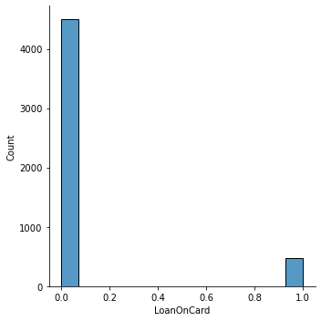

```python
#plt.figure(figsize=(17,10))
sns.displot(df2['LoanOnCard'])
```

###### The Target has either zero or 1

###### The target has very less null values to impute

##### B. Check the percentage of missing values and impute if required

```python
df2.isnull().sum()/100
```

```
ID                     0.0
Age                    0.0
CustomerSince          0.0
HighestSpend           0.0
ZipCode                0.0
HiddenScore            0.0
MonthlyAverageSpend    0.0
Level                  0.0
Mortgage               0.0
Security               0.0
FixedDepositAccount    0.0
InternetBanking        0.0
CreditCard             0.0
LoanOnCard             0.2
dtype: float64
```

```python
#df2['LoanOnCard'] = df2['LoanOnCard'].dropna()
df2.dropna(subset=['LoanOnCard'], inplace=True)
df2['LoanOnCard'].isnull().sum()/100
```

```
0.0
```

##### C. Check for unexpected values in each categorical variable and impute with best suitable value

```python
for column in ['CreditCard','InternetBanking','FixedDepositAccount','Security','Level','HiddenScore']:
        print(f"{column} unique values are {df2[column].unique()}")
```

```
CreditCard unique values are [0, 1]
Categories (2, int64): [0, 1]
InternetBanking unique values are [0, 1]
Categories (2, int64): [0, 1]
FixedDepositAccount unique values are [0, 1]
Categories (2, int64): [0, 1]
Security unique values are [0, 1]
Categories (2, int64): [0, 1]
Level unique values are [3, 2, 1]
Categories (3, int64): [1, 2, 3]
HiddenScore unique values are [1, 4, 3, 2]
Categories (4, int64): [1, 2, 3, 4]
```

###### There is no unexpected value

### Data Preparation and model building

##### A. Split data into X and Y. [Recommended to drop ID & ZipCode. LoanOnCard is target Variable]

```python
df2.drop('ID',inplace=True, axis=1)
df2.drop('ZipCode',inplace=True, axis=1)
X2 = df2.drop('LoanOnCard',axis=1)
Y2 = df2['LoanOnCard']

print(X2.sample(2))
print(Y2.sample(2))
X2.info()
```

```
      Age  CustomerSince  HighestSpend HiddenScore  MonthlyAverageSpend Level  \
829    55             30            81           4                  3.8     2
4298   43             19           122           1                  0.3     1

      Mortgage Security FixedDepositAccount InternetBanking CreditCard
829          0        0                   0               1          0
4298         0        0                   0               1          0
2114    0.0
4178    0.0
Name: LoanOnCard, dtype: float64
<class 'pandas.core.frame.DataFrame'>
Int64Index: 4980 entries, 9 to 4999
Data columns (total 11 columns):
 #   Column               Non-Null Count  Dtype
---  ------               --------------  -----
 0   Age                  4980 non-null   int64
 1   CustomerSince        4980 non-null   int64
 2   HighestSpend         4980 non-null   int64
 3   HiddenScore          4980 non-null   category
 4   MonthlyAverageSpend  4980 non-null   float64
 5   Level                4980 non-null   category
 6   Mortgage             4980 non-null   int64
 7   Security             4980 non-null   category
 8   FixedDepositAccount  4980 non-null   category
 9   InternetBanking      4980 non-null   category
 10  CreditCard           4980 non-null   category
dtypes: category(6), float64(1), int64(4)
memory usage: 263.4 KB
```

##### B. Split data into train and test. Keep 25% data reserved for testing.

```python
X2_train, X2_test, y2_train, y2_test = train_test_split(X2, Y2, test_size=0.25, random_state=1)
# 1 is just any random seed number

print(f"{X2_train.shape} is X2_train shape {X2_test.shape} X2_test shape "
      f"{y2_train.shape} is y2_train shape {y2_test.shape} y2_test shape")
X2_train.head()
```

```
(3735, 11) is X2_train shape (1245, 11) X2_test shape (3735,) is y2_train shape (1245,) y2_test shape
```

|  | Age | CustomerSince | HighestSpend | HiddenScore | MonthlyAverageSpend | Level | Mortgage | Security | FixedDepositAccount | InternetBanking | CreditCard |
| --- | --- | --- | --- | --- | --- | --- | --- | --- | --- | --- | --- |
| 3980 | 46 | 22 | 89 | 4 | 1.4 | 2 | 0 | 0 | 0 | 1 | 0 |
| 4489 | 39 | 13 | 21 | 3 | 0.2 | 2 | 0 | 0 | 0 | 1 | 0 |
| 4414 | 33 | 8 | 178 | 3 | 8.5 | 1 | 0 | 1 | 1 | 1 | 0 |
| 877 | 35 | 11 | 59 | 4 | 0.1 | 2 | 0 | 0 | 0 | 0 | 0 |
| 4390 | 52 | 26 | 62 | 4 | 2.8 | 2 | 0 | 0 | 0 | 1 | 0 |

##### C. Train a Supervised Learning Classification base model - Logistic Regression

```python
# Fit the model on train
model = LogisticRegression(solver="liblinear")
model.fit(X2_train, y2_train)
y2_predict = model.predict(X2_test)
model_score = model.score(X2_test, y2_test)
print(model_score)
```

```
0.9477911646586346
```

```python
train_model_score = model.score(X2_train, y2_train)
print(train_model_score)
```

```
0.951004016064257
```

```python
print(f"accuracy = {accuracy_score(y2_test, y2_predict)} precision = "
      f"{precision_score(y2_test, y2_predict,average='weighted')}, recall = "
      f"{recall_score(y2_test, y2_predict,average='weighted')}, f1 = "
      f"{f1_score(y2_test, y2_predict,average='weighted')}")
print("classification  Matrix:\n",classification_report(y2_test,y2_predict))
```

```
accuracy = 0.9477911646586346 precision = 0.9445714420501207, recall = 0.9477911646586346, f1 = 0.943503449011995
classification  Matrix:
               precision    recall  f1-score   support

         0.0       0.96      0.99      0.97      1118
         1.0       0.85      0.59      0.70       127

    accuracy                           0.95      1245
   macro avg       0.90      0.79      0.83      1245
weighted avg       0.94      0.95      0.94      1245
```

###### The score is high and almost equal with both train and test data.

##### D. Print evaluation metrics for the model and clearly share insights

```
0.0    1118
1.0     127
Name: LoanOnCard, dtype: int64
[[1105   13]
 [  52   75]]
```

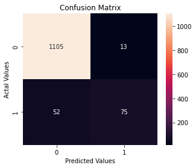

```python
cm = metrics.confusion_matrix(y2_test, y2_predict)
np.set_printoptions(threshold=np.inf)
print(y2_test.value_counts())
print(cm)
cm_df = pd.DataFrame(cm,
                     index = ['0','1'])
plt.figure(figsize=(5,4))
sns.heatmap(cm_df, fmt='g', annot=True)
plt.title('Confusion Matrix')
plt.ylabel('Actal Values')
plt.xlabel('Predicted Values')
plt.show()
```

##### E. Balance the data using the right balancing technique

###### i. Check distribution of the target variable

###### ii. Say output is class A : 20% and class B : 80%

###### iii. Here you need to balance the target variable as 50:50.

###### iv. Try appropriate method to achieve the same.

```
0.0    4500
1.0     480
Name: LoanOnCard, dtype: int64
```

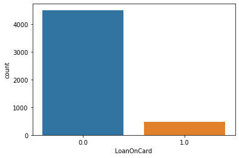

```python
print(df2['LoanOnCard'].value_counts())
sns.countplot(x=df2['LoanOnCard'])
```

###### There are 4.5 K records are saying many customers do not have loan on their card

###### The distribution is not balanced

```python
#!pip install imblearn
#conda install -c conda-forge imbalanced-learn
from imblearn.over_sampling import SMOTENC
```

```python
X2_resampled , Y2_resampled = SMOTENC(categorical_features=[3,5,7,8,9,10]).fit_resample(X2, Y2)
```

```python
print(X2_resampled.sample(n=5))
print(Y2_resampled.value_counts())
```

```
      Age  CustomerSince  HighestSpend HiddenScore  MonthlyAverageSpend Level  \
6624   58             33           154           3             2.612667     3
7983   47             22           161           4             6.608199     1
8057   52             26           193           2             5.848616     3
2934   31              7            42           1             2.400000     2
1925   57             33            30           3             1.500000     1

      Mortgage Security FixedDepositAccount InternetBanking CreditCard
6624         0        0                   0               0          0
7983       308        0                   0               1          0
8057         0        0                   0               1          0
2934         0        0                   0               1          1
1925       151        1                   0               1          0
1.0    4500
0.0    4500
Name: LoanOnCard, dtype: int64
```

##### F. Again train the same previous model on balanced data.

```python
X3_train, X3_test, y3_train, y3_test = train_test_split(X2_resampled, Y2_resampled, test_size=0.25, random_state=1)
# 1 is just any random seed number

print(f"{X3_train.shape} is X3_train shape {X3_test.shape} X3_test shape "
      f"{y3_train.shape} is y3_train shape {y3_test.shape} y3_test shape")
X3_train.head()

# Fit the model on train
model = LogisticRegression(solver="liblinear")
model.fit(X2_resampled, Y2_resampled)
y3_predict = model.predict(X3_test)
model_score = model.score(X3_test, y3_test)
print(model_score)

print(f"accuracy = {accuracy_score(y3_test, y3_predict)} precision = "
      f"{precision_score(y3_test, y3_predict,average='weighted')}, recall = "
      f"{recall_score(y3_test, y3_predict,average='weighted')}, f1 = "
      f"{f1_score(y3_test, y3_predict,average='weighted')}")
print("classification  Matrix:\n",classification_report(y3_test,y3_predict))
```

```
(6750, 11) is X3_train shape (2250, 11) X3_test shape (6750,) is y3_train shape (2250,) y3_test shape
0.9044444444444445
accuracy = 0.9044444444444445 precision = 0.9044463501221784, recall = 0.9044444444444445, f1 = 0.904445218583527
classification  Matrix:
               precision    recall  f1-score   support

         0.0       0.90      0.90      0.90      1104
         1.0       0.91      0.91      0.91      1146

    accuracy                           0.90      2250
   macro avg       0.90      0.90      0.90      2250
weighted avg       0.90      0.90      0.90      2250
```

##### G. Print evaluation metrics and clearly share differences observed.

###### The precision - recall and f1-score is increased and matching with Class '0'

### Performance Improvement

#### A. Train a base model each for SVM, KNN.

##### Using KNN

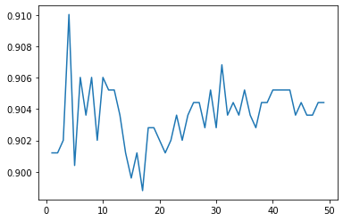

```python
scores =[]
for k in range(1,50):
    NNH = KNeighborsClassifier(n_neighbors = k, weights = 'distance' )
    NNH.fit(X2_train, y2_train)
    scores.append(NNH.score(X2_test, y2_test))
plt.plot(range(1,50),scores)
```

```python
NNH = KNeighborsClassifier(n_neighbors=3, p=1, weights = 'distance')
NNH.fit(X2_train, y2_train)
knn_predicted_labels = NNH.predict(X2_test)
NNH.score(X2_test, y2_test)
print(f"accuracy = {accuracy_score(y2_test, knn_predicted_labels)} precision = "
      f"{precision_score(y2_test, knn_predicted_labels,average='weighted')}, recall = "
      f"{recall_score(y2_test, knn_predicted_labels,average='weighted')}, f1 = "
      f"{f1_score(y2_test, knn_predicted_labels,average='weighted')}")
print("classification  Matrix:\n",classification_report(y2_test,knn_predicted_labels))
```

```
accuracy = 0.9140562248995984 precision = 0.9011540906450469, recall = 0.9140562248995984, f1 = 0.9032111979720183
classification  Matrix:
               precision    recall  f1-score   support

         0.0       0.93      0.98      0.95      1118
         1.0       0.64      0.36      0.46       127

    accuracy                           0.91      1245
   macro avg       0.78      0.67      0.71      1245
weighted avg       0.90      0.91      0.90      1245
```

#### Use SVM

###### How to choose gamma and C ??

```python
from sklearn import svm
```

```python
svm_clf = svm.SVC();
svm_clf.fit(X2_train , y2_train)
svm_y_pred = svm_clf.predict(X2_test)
print(f"accuracy = {accuracy_score(y2_test, svm_y_pred)} precision = "
      f"{precision_score(y2_test, svm_y_pred,average='weighted')}, recall = "
      f"{recall_score(y2_test, svm_y_pred,average='weighted')}, f1 = "
      f"{f1_score(y2_test, svm_y_pred,average='weighted')}")
print("classification  Matrix:\n",classification_report(y2_test,svm_y_pred))
```

```
accuracy = 0.9028112449799197 precision = 0.8807289566428981, recall = 0.9028112449799197, f1 = 0.8696590327968962
classification  Matrix:
               precision    recall  f1-score   support

         0.0       0.91      0.99      0.95      1118
         1.0       0.65      0.10      0.18       127

    accuracy                           0.90      1245
   macro avg       0.78      0.55      0.56      1245
weighted avg       0.88      0.90      0.87      1245
```

```python
svm_clf = svm.SVC(gamma='auto', C=3)
svm_clf.fit(X2_train , y2_train)
svm_y_pred = svm_clf.predict(X2_test)
print(f"accuracy = {accuracy_score(y2_test, svm_y_pred)} precision = "
      f"{precision_score(y2_test, svm_y_pred,average='weighted')}, recall = "
      f"{recall_score(y2_test, svm_y_pred,average='weighted')}, f1 = "
      f"{f1_score(y2_test, svm_y_pred,average='weighted')}")
print("classification  Matrix:\n",classification_report(y2_test,svm_y_pred))
```

```
accuracy = 0.9068273092369478 precision = 0.8925552348153019, recall = 0.9068273092369478, f1 = 0.8765979473449352
classification  Matrix:
               precision    recall  f1-score   support

         0.0       0.91      0.99      0.95      1118
         1.0       0.74      0.13      0.23       127

    accuracy                           0.91      1245
   macro avg       0.82      0.56      0.59      1245
weighted avg       0.89      0.91      0.88      1245
```

##### B. Tune parameters for each of the models wherever required and finalize a model. (Optional: Experiment with various Hyperparameters - Research required)

##### With the above understanding,

##### The KNN was tried with optimal K value and the accuracy and other performance matrix are still lower than the Logistic

##### The SVM is tried with default different C value and the performance matrix suggest that it gives improved Precision but recall/f1-score is lower than KNN

##### C. Print evaluation metrics for final model.

```
0.9477911646586346
0.951004016064257
accuracy = 0.9477911646586346 precision = 0.9445714420501207, recall = 0.9477911646586346, f1 = 0.943503449011995
classification  Matrix:
               precision    recall  f1-score   support

         0.0       0.96      0.99      0.97      1118
         1.0       0.85      0.59      0.70       127

    accuracy                           0.95      1245
   macro avg       0.90      0.79      0.83      1245
weighted avg       0.94      0.95      0.94      1245

0.0    1118
1.0     127
Name: LoanOnCard, dtype: int64
[[1105   13]
 [  52   75]]
```

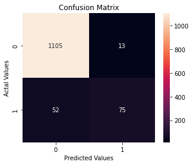

```python
# Fit the model on train
model = LogisticRegression(solver="liblinear")
model.fit(X2_train, y2_train)
y2_predict = model.predict(X2_test)
model_score = model.score(X2_test, y2_test)
print(model_score)
train_model_score = model.score(X2_train, y2_train)
print(train_model_score)
print(f"accuracy = {accuracy_score(y2_test, y2_predict)} precision = "
      f"{precision_score(y2_test, y2_predict,average='weighted')}, recall = "
      f"{recall_score(y2_test, y2_predict,average='weighted')}, f1 = "
      f"{f1_score(y2_test, y2_predict,average='weighted')}")
print("classification  Matrix:\n",classification_report(y2_test,y2_predict))
cm = metrics.confusion_matrix(y2_test, y2_predict)
np.set_printoptions(threshold=np.inf)
print(y2_test.value_counts())
print(cm)
cm_df = pd.DataFrame(cm,
                     index = ['0','1'])
plt.figure(figsize=(5,4))
sns.heatmap(cm_df, fmt='g', annot=True)
plt.title('Confusion Matrix')
plt.ylabel('Actal Values')
plt.xlabel('Predicted Values')
plt.show()
```

##### Following is the confusion matrix for Resampled Data

```
1.0    1146
0.0    1104
Name: LoanOnCard, dtype: int64
[[ 997  107]
 [ 108 1038]]
```

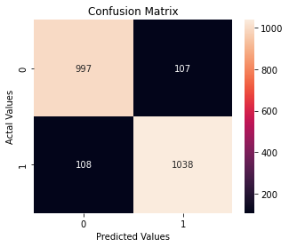

```python
cm = metrics.confusion_matrix(y3_test, y3_predict)
np.set_printoptions(threshold=np.inf)
print(y3_test.value_counts())
print(cm)
cm_df = pd.DataFrame(cm,
                     index = ['0','1'])
plt.figure(figsize=(5,4))
sns.heatmap(cm_df, fmt='g', annot=True)
plt.title('Confusion Matrix')
plt.ylabel('Actal Values')
plt.xlabel('Predicted Values')
plt.show()
```